# Estimating the reproductive number of the COVID-19 epidemic in Switzerland

Antoine Bourret

15/01/2021

## Introduction

We will estimate the reproductive number of the COVID-19 in Switzerland, denoted $R_t$, which represents the average number of secondary cases caused by the infection of an individual at a particular time $t$. We will use the number of daily new cases to estimate $R_t$, using generalized additive models with smoothing splines. In the following, we denote the reported curve (also called the observed cases) by $\{Y_t\}_{t=1}^T$ and the true incidence curve by $\{I_t\}_{t=1}^T$. These curves are assumed to be discretized in time, and are monitored and estimated on a daily basis. However, these curves are not necessarily equal, as some individuals might be asymptomatic, and are thus not reported as infected. As such, the reported number of cases at some point in time might not be representative of the number of individuals that were infected, due to delay between the infection event and the symptom onset. Thus, we need to deconvolve the incidence curve before estimating $R_t$, that is, estimate the true infection events from the observed ones, given a distribution for the incubation period. This is the first part of this notebook In the second one, we estimate the reproductive number.

## Getting the data

We use data from the [Federal Office of Public Health](https://www.covid19.admin.ch/en/overview), which are updated every day, including during weekends. Also, here are the libraries that we will need for the analysis:

```r
library(ggplot2)
library(shinythemes)
library(openxlsx)
library(readr)
library(cowplot)
library(zoo)
library(mgcv)
library(latex2exp)
library(splines)
require(stats)
require(graphics)
```

Now we can load the data. We use the function `ConstructDataset`, and take infection events from March to December 2020.

```r
swiss_data <- ConstructDataset("Switzerland")

data_cases <- swiss_data$new_confirmed   # new confirmed cases
data_dates <- swiss_data$Date   # list of dates
indices <- c(1:303)   # we take only data from March to December 2020
```

Below is a plot of the incidence curve, to get an idea of the type of data we are dealing with. We can distinguish the two epidemiological waves, and most importantly a strong weekly pattern, characterized by a drop of reported cases during the weekends. We also add a small extension of 20 days at the end. This will be usefull for the deconvolution part.

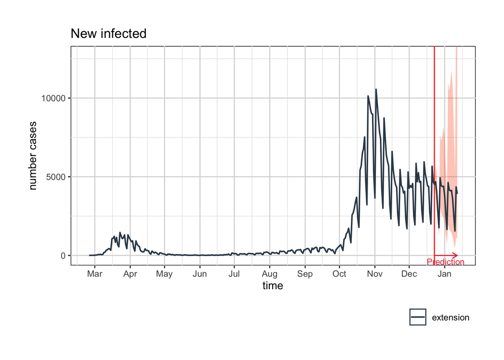

```r
prediction_window <- 20

# Infection events:
extensionSwiss <- extension_prediction(data_cases[indices],
                                       extension = list('len' = prediction_window,
                                                        'family' = nb(link = 'log'),
                                                        'keep_original' = TRUE,
                                                        'min_weights' = 0.1),
                                       fm = "cases ~ s(time, k = 100, bs = \'tp\', m = c(0, 1)) + s(day, k = 5)")

# Plot of the incidence curve
infected_plot <- plot_country(extensionSwiss, indices, title="New infected", x="time", y="number cases",
                              times = seq.Date(data_dates[1], as.Date(data_dates[length(indices)]) + prediction_window, by = "1 day"))
infected_plot
```

## Deconvolution of the incidence curve

For the deconvolution, we assume that the observed event $Y_t+1$ follows, conditionally on the incidence events $I_1, \ldots, I_t$, a Poisson distribution with a weighted sum of these incidence events. More formally, we assume that $Y_{t+1} | I_1, \ldots, I_{t} \sim \text{Pois}(\mu_{t+1})$, with $\mu_{t+1} = \sum_{s=1}^K {w_s I_{t+1-s}}$. The distribution $F$ of the incubation period is taken as known ($F(s) = w_s$). In a vectorized form, we can define $I = \{I_t\}_{t=1}^{T} \in \mathbb{R}^T$ to be the vector of incidence events, and $\mu = [\mu_1, \ldots, \mu_T]^T \in \mathbb{R}^T$ the vector of mean of the Poisson random vector. Then, according to the definition of the model, we have that $B I = \mu$, with the incubation period matrix
$$B =
\begin{bmatrix}
w_1 & & & & \\
\vdots & \ddots & & 0 & \\
w_K & \ldots & w_1 & & \\
& \ddots& & \ddots & \\
0 & & w_K & \ldots& w_1\\
\end{bmatrix}
\in \mathbb{R}^{T \times T}.$$
For the incubation period, we can use estimates from [Lauer et al.](https://doi.org/10.7326/M20-0504), with a mean of 5.1 days and 95% confidence interval 4.1-5.8 days. We use a discretized gamma distribution:

```r
# Incubation period distribution:
shape_w_conv <- 10.2
scale_w_conv <- 0.5
w_conv<- discrete_gamma(shape = shape_w_conv, scale = scale_w_conv)
```

The parameters $\{I_t\}_{t=1}^{T}$ can then be estimated by maximizing the log likelihood, using the conjugate gradient descent or the Broyden-Fletcher-Goldfarb-Shanno (BFGS) algorithm. However, this implies that there are as many parameters as there are variables, which can in practice lead to unstable estimates. Thus, we assume that the true incidence curve is a smooth function of time, that we will model using spline functions. Formally, we set $I = Z\gamma$, where $Z$ is the spline basis matrix in $\mathbb{R}^{T \times q}$ and $\gamma$ are the parameters associated with the spline basis, in $\mathbb{R}^q$. The only parameters to be estimated are the $\gamma$, with $B Z \gamma = \mu$. This is of generalized additive form, and we can use the `gam` function from the `mgcv` package to estimate the parameters.

The update rule for the parameters is
$$\gamma_{\lambda}^{k+1} = \left( (BZ)^T W BZ + \lambda\Delta \right)^{-1} (BZ)^T W (BZ \gamma_{\lambda}^k + (Y - BZ\gamma_{\lambda}^k)/BZ\gamma^k)$$
with $W = \text{diag}(BZ\gamma^k)$ the diagonal matrix in $\mathbb{R}^{T\times T}$, which depends on the current estimate of the parameters. $B$ corresponds to the incubation period matrix. The term $\Delta$ is a penalization matrix, which is here tridiagonal. We can chose the $\lambda$ parameter and the basis dimension $q$ with cross-validation, which are carried by the two functions below `findBestDimension` and `findBestLambda`. To allow for overdispersion, we use a quasi-Poisson model.

```r
#
# First, we add some values set to 1 before the beginning of the epidemic, so that the spline functions do not have too much variability during the initial phase
extension_first_length <- 20
indices_extension_start <- c(c(1:extension_first_length), extension_first_length + indices)
data_cases_extension_start <- c(rep(1, extension_first_length), data_cases)
new_dates <- seq.Date(data_dates[1] - extension_first_length, length=length(indices) + extension_first_length, by= '1 day')
original_indices_translated <- extension_first_length + indices

# Now we search for the best basis dimension, as well as the best penalization based on the chosen dimension
dimensionBasis <- findBestDimension(data_cases_extension_start[indices_extension_start],   # observed data
                                    prob_vector = w_conv,  # incubation period
                                    family = quasipoisson(link = 'log'), # family for the GAM
                                    smoothing = 7, # smoothing window for the observation
                                    extension = list('len' = 40, 'family' = nb(link = 'log'), 'keep_original' = TRUE, 'min_weights' = 0.1),  # extension parameters
                                    range_values = c(30:150),  # values for the grid search
                                    diagnostic_plot = FALSE,   # TRUE to show the score for each values of the basis dimension
                                    fm = "cases ~ s(time, k = 50, bs = \'tp\', m = c(0, 0)) + s(day, k = 5)")  # the formula for the extension

lambda_delta <- findBestLambda(data_cases_extension_start[indices_extension_start], # observed data
                               k_spline = dimensionBasis,    # basis dimension
                               prob_vector = w_conv,  # incubation period
                               range_values = 10**(20:-10),  # values for the grid search
                               family = quasipoisson(link = 'log'), # family for the GAM
                               smoothing = 7,  # smoothing window for the observation
                               extension = list('len' = 40, 'family' = nb(link = 'log'), 'keep_original' = TRUE, 'min_weights' = 0.1),  # extension parameters
                               diagnostic_plot = FALSE,   # TRUE to show the score for each values of the basis dimension
                               fm = "cases ~ s(time, k = 50, bs = \'tp\', m = c(0, 0)) + s(day, k = 5)")   # the formula for the extension

# Once the best lambda is found, we construct the regularization matrix Delta
delta <- construct_delta(dimensionBasis + 4)
delta <- lambda_delta * delta

# Here is the function to estimate the true incidence events
results_IWLS_extended <- DeconvolutionGAM(data_cases_extension_start[indices_extension_start],
                                          w_conv,
                                          dimensionBasis,
                                          plot_ = FALSE,
                                          delta = delta,
                                          get_derivatives = FALSE,
                                          family = quasipoisson(link = 'log'),
                                          extension = list('len' = 40, 'family' = nb(link = 'log'), 'keep_original' = TRUE, 'min_weights' = 0.1),
                                          fm = "cases ~ s(time, k = 100, bs = \'tp\', m = c(0, 1)) + s(day, k = 5)")

# We compute here the confidence bands (point-wise and simultaneous)
ConfidenceBands_extended <- SimultaneousIntervals(results_IWLS_extended$SplineBasis,
                                                  plot_ = TRUE,
                                                  coefficients_model = results_IWLS_extended$fit$coefficients,
                                                  CovMatrix = vcov(results_IWLS_extended$fit),
                                                  sample_splines = TRUE,
                                                  ilink_fct = family(results_IWLS_extended$fit)$linkinv,
                                                  N_keep = 100)
```

```r
sprintf("One parameter approximately every %.3f days", length(data_cases_extension_start[indices_extension_start])/dimensionBasis)
```

```
## [1] "One parameter approximately every 5.981 days"
```

And here are the estimated true incidence events:

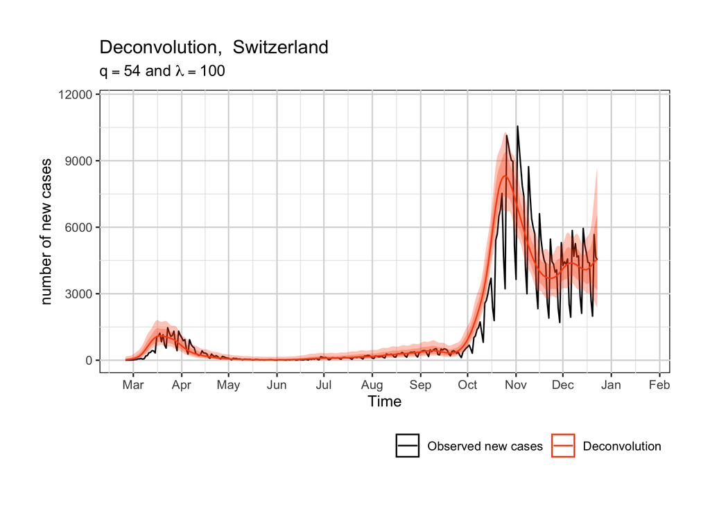

```r
plot_deconvolution <- ggplot(data = NULL, aes(x = new_dates[original_indices_translated], y = data_cases_extension_start[original_indices_translated], colour = "Observed new cases")) + geom_line() +
  geom_ribbon(aes(ymin = ConfidenceBands_extended$Point_wise_CI_lower[original_indices_translated], ymax = ConfidenceBands_extended$Point_wise_CI_upper[original_indices_translated], fill = "Point-wise confidence bands", colour = NA), alpha = 0.3, fill = colors[3]) +
  geom_ribbon(aes(ymin = ConfidenceBands_extended$Simultaneous_lower[original_indices_translated], ymax = ConfidenceBands_extended$Simultaneous_upper[original_indices_translated], fill = "Simlutaneous confidence bands", colour = NA), alpha = 0.3, fill = colors[3]) +
  geom_line(aes(y = results_IWLS_extended$fitted_values[original_indices_translated], colour = 'Deconvolution')) +
  scale_colour_manual("",
                      breaks = c("incidence", 'Observed new cases', 'Deconvolution', "Point-wise confidence bands", "Simlutaneous confidence bands"),
                      values = c("black", "black", colors[3], colors[3], colors[3])) +
  scale_fill_manual("",
                    breaks = c("Point-wise confidence bands", "Simlutaneous confidence bands"),
                    values = c(colors[3], colors[3])) +
  labs(title=paste("Deconvolution, ", settings$country), x="Time", y="number of new cases", subtitle = latex2exp::TeX(paste("$q = ", dimensionBasis, "$ and $\\lambda = ", lambda_delta, "$"))) +
  theme_for_the_plots +
  coord_cartesian(ylim = c(0, 1.1 * max(data_cases)), xlim = c(data_dates[1], as.Date("2021-01-22"))) +
  guides(color=guide_legend(override.aes=list(fill=NA))) +
  theme(legend.position="bottom") +
  scale_x_date(date_breaks = "1 month", date_labels = "%b")

plot_deconvolution
```

## Estimating $R_t$

Analogously to the deconvolution step, we estimate $R_t$ with spline functions. In our model, we assume that the mean number of newly infected individuals at time $t$ is a weighted average of the new infected individuals at previous time step, multiplied by some quantity $R_t$ that varies across time. More formally, let $I_t$ be the incidence curve for time step $t = 1, \ldots, T$, and let $\{\tilde{w}_j\}_{j=1}^{K}$ be the infectivity profile, which is different from the incubation period that we introduced earlier. We suppose that each $I_t$ is Poisson distributed, with mean
$$\mu_t = R_t \sum_{j=1}^{K}\tilde{w}_j I_{t-j} = \exp \left[ \log(R_t) + \log \left (\sum_{j=1}^{K}\tilde{w}_j I_{t-j} \right ) \right ],$$
where the generation interval is assumed to be known. As such, the second term in the exponential (the offset) can be explicitly computed, and the only unknown is the log of the reproductive number. In order to estimate this, we suppose that $\log(R_t)$ is smoothed over the time, that is,
$$\log(R_t) = \sum_{i = 1}^{q_1}\beta_j B_j(t),$$
where $B = \{B_1,\ldots,B_{q_1}\}$ is a spline basis of dimension $q_1$, defined over the interval $[0, T]$.

For the generation intervals, we can use estimates from [Tapiwa et al.](https://www.medrxiv.org/content/early/2020/03/08/2020.03.05.20031815), with a mean of 5.2 days (95%CI 3.78-6.78) and standard deviation 1.72 (95%CI 0.91-3.93):

```r
# The genration interval
W_gam <- discrete_normal()$prob_vector
```

Here is the code to estimate $R_t$ using spline functions. We first compute the offset values and the weights. These weights are computed based on the variance of the estimated incidence events (from the deconvolution step), so that observations with large variance (and confidence bands) are less reliable and should then have their impact reduced in the fitting routine. This is controled by the parameter `weights` in the `gam` function. We multiply the weights with the square root of the fitted values in order to balance the use of a quasi-Poisson model in the deconvolution, which allowed to have a variance that is a linear function of the mean (but not equal to the mean, as it is assumed for a Poisson model).

```r
# These are the offset values
offsetValues_IWLS <- convolve(c(0* 1:(length(W_gam)-1), Swiss_deconvolution), rev(W_gam), type = "filter")
offsetValues_IWLS[which(offsetValues_IWLS <= 0)] <- 1

# Weights for the fit
weights <- abs(condidence_bands$Point_wise_CI_upper[indices_used] - condidence_bands$Point_wise_CI_lower[indices_used])/4  # get standard errors from CI
weights <- weights**2
weights <- weights /sqrt(results_deconvolution$fitted_values[indices_used])
weights <- 1/weights
weights <- weights/mean(weights)

# Data frame containing the response variable, the offset and the time indices
DAT_IWLS <- data.frame(resp = results_deconvolution$fitted_values[indices_used], offs = offsetValues_IWLS, x = c(1:length(results_deconvolution$fitted_values[indices_used])))

# We fit the model, using a negative binomial model and a basis dimension of 70
fit_IWLS <- fitModel(DAT_IWLS,
                     which_model = nb(link = "log"),   # negative binomial model with log link function
                     weights_ = weights,               # weights for the P-IWLS algorithm
                     fm = 'resp ~ s(x, k = 70)',       # basis dimension: 70
                     ignore_first_max = 10,            # for the plots, we ignore first 10 largest values
                     deriv_plots = c(0,1),             # we compute the fitted values (R_t) and its derivative
                     detect_flat = TRUE,               # plot option
                     axis_x = data_dates[indices])     # plot option
```

And here are the estimates for $R_t$ (top panel), along with its first derivative (bottom panel), which is computed using a finite difference scheme. The estimate is shown by the solid yellow curve, with in light red the point-wise and simultaneous confidence intervals. The solid black curves are splines curves sampled from the estimates of the parameters of the model. The grey regions correspond to period where the critical threshold (either 1 for the fitted values in (top), or 0 for the derivatives in (bottom)) is between the confidence bands. The main restrictive measures are shown with dashed vertical lines, so as to assess their effectiveness.

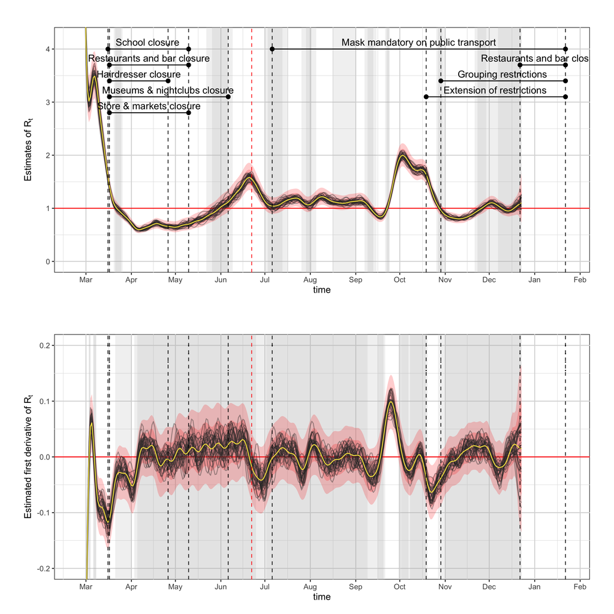

```r
plot_grid(plot_estim_r,
          plot_estim_r_deriv,
          nrow = 2, align = 'hv')
```